# Seven Things That Affect Education Around the World

Luke Fostveldt, Alex Shum, Ian Lyttle, Di Cook

Reducing inequities in education outcomes is of great interest to politicians. Dissecting the causes of inequality is a much tougher challenge with no panacea. Nonetheless, tackling inequality in educational outcomes is essential from both moral and economic viewpoints. The Programme for International Student Assessment (PISA) is a triennial survey conducted by the Organization for Economic Cooperation and Development (OECD) with a rotating additional emphasis on one of mathematics, reading, and science. In 2012, the additional emphasis was on mathematics. All 34 member countries of the OECD and 31 partnering countries and economies participated in the survey. This represents over 80% of the global economy. The OECD estimates that if all students could reach a level-2 proficiency in mathematics – a level-2 proficiency means that a student can only handle the ``simplest and most obvious tasks" – it would add a collective US$200 trillion to the world’s collective GDP.

The OECD describes the PISA survey as ``the world’s global metric for quality, equity and efficiency in school education" (citep[p. 3]{PISA2014a}). The goal of the PISA survey is to assess the workforce readiness of 15-year old students. Nearly 500,000 students were tested across the 65 countries and economies. Students are examined on how well they can apply the knowledge they learned in school to applications outside of school. The scores reported range between 0-1000. Additional information about the students, parents, and schools is also collected. The students completed a questionnaire providing information about themselves, their homes, their schools, and a variety of psychological views regarding factors they believe affects their performance in school. Schools principals responded to a questionnaire covering the school system and learning experiences for students. In some countries, parents completed a questionnaire requesting information about their perceptions regarding the school system, expectations for their child, and their involvement in their child’s schooling.

The data was made available by the OECD as part of a data challenge for the useR! 2014 conference. Entries to the competition can be found at http://beta.icm.edu.pl/PISAcontest/. We learned a lot from this data, and won one of the prizes. This is a description of the seven main things we learned about 15 year olds, their math, science and reading skills, and the effects of other factors.

### The gender gap in math is not universal but the reading gap is, in favor of girls

For each country, average scores on math and reading are calculated separately for boys and girls. These averages are differenced to compute the “gap” between boys and girls. T-statistics were calculated to determine the statistical significance of the difference. The results are plotted in the graphs below. Each dot corresponds to a difference between girls and boys scores, for each country. Color indicates statistical significance (blue in favor of boys, pink in favor of girls and green means there was no significant difference). The size of the dot indicates the proportion of boys in the sample size. For most countries it is roughly equal, but some countries have an imblance, for example, Malaysia has more girls tested than boys. The maps color the countries by the presence of a gender gap.

Conversely, though, when we look at reading scores the story is entirely different. Universally, girls score significantly better than boys. Again, the size of the gap is small, between 10 and 80 points.

Although, not shown here, it also should be noted that this is the difference between the average scores for boys and girls. There is a slightly different story for each country if we look at the top math score for each geneder only, where we would notice that the top score in the USA is achieved by a girl, and is substantially higher than the highest boys score. There is far more individual variability than the overall average differences.

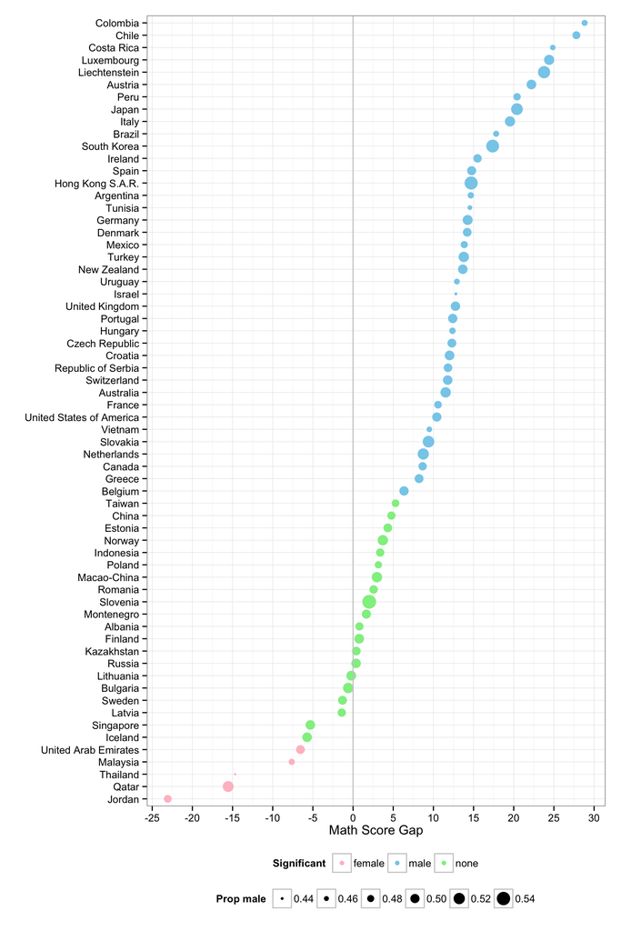

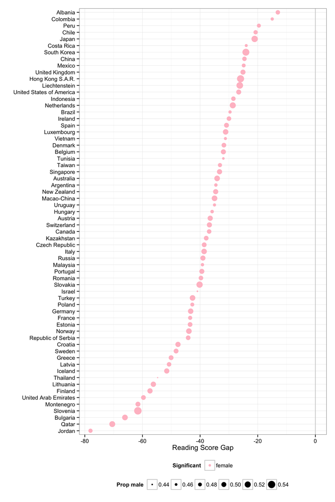

[figure not shown]

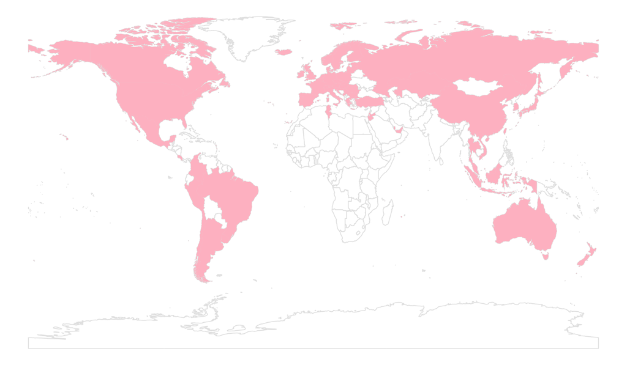

### Starting school at an older age generated lower average math score.

For each country we have computed the average math test score by age that the children started school. In additon, for each country we computed the median age that children in the study started school. There are differences in typical school start age between countries. Ireland has the youngest median start age - children head to school at age 4. Britain, and its past colonies, Australia, Canada and New Zealand, have a median start age of 5. For many other countries the median start age is 6, and for northern Europe, much of Asia and Brazil median start age is as late as 7. Some countries appear to have rigid starting ages, eg in Japan all children start at age 6.

Within a country, looking at the average math score for each start age, the score typically declines, especially after age 6. This is almost uniformly the pattern across all of the countries in the study. For several countries - Russia, Denmark, Bulgaria - if a child starts school at age 4 their math scores were much better on average than another other starting age group. School start age matters, that children need to start school in the 4-6 age range to expect better math scores, on average.

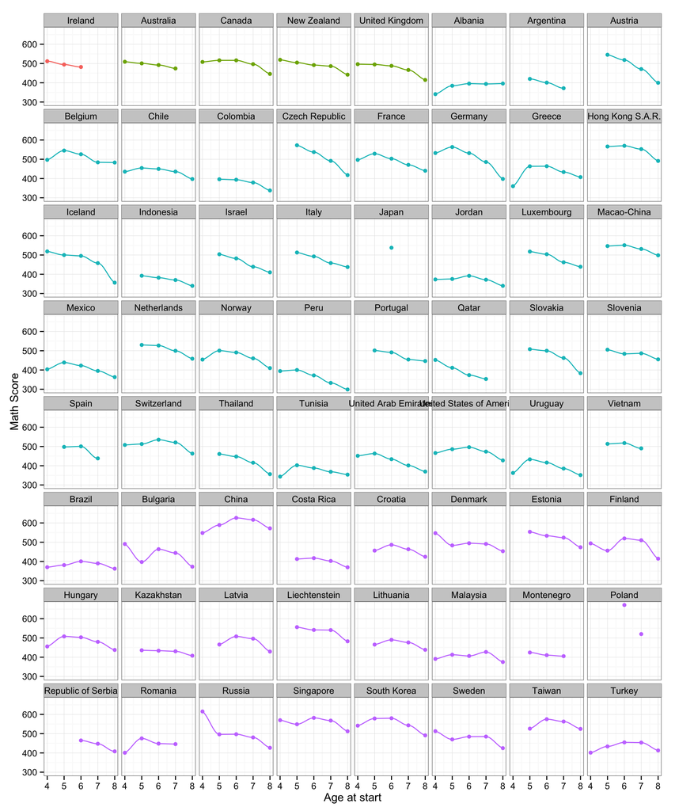

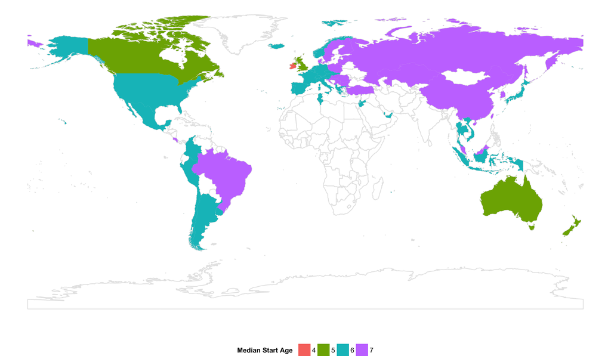

### More TVs yield higher math scores in the developing world, but lower in the developed countries

It seems that television is the great equalizer. As part of our investigation, we set out to explore how household factors, as indicators of inequality, affect student test scores.

Math scores correlate with the number of household TVs, but how depends on where you live. Nevertheless, access to a quiet study space is generally a plus.

For each country, students’ math scores are compared with number of TVs at home. Countries are grouped by direction and strength of the correlation; groups of countries are mapped (above) and identified (right).

Students are considered by group, and categorized by household factors: number of TVs, and access to a quiet study space. At far left, number of students in each category; at near left, math scores are summarized for students in each category.

[figure not shown]

Find your own correlations: http://bit.ly/pisa2012_explorer

### Play with the data yourself

Shiny app

### Acknowledgements

Software packages